# Bayesian Psychometric

Olsson et al.

11/1/2019

The model object used in these analyses is stored in ‘results/Psychometric_Bayesian_model_object.rds’. To use it, load it into an object named: ‘Bayes.fit’.

```r
library('readr')
library('tidyr')
library('magrittr')
library('rstan')
rstan_options(auto_write = TRUE)
options(mc.cores = parallel::detectCores())
Sys.setenv(LOCAL_CPPFLAGS = '-march=corei7 -mtune=corei7')
library('brms')
cd.long <- read_delim('colour_discriminate_long_format.txt', delim="\t")
```

Success in each trial is either TRUE or FALSE.

```r
summary(cd.long)
```

```
##  Colour.difference  background          stimuli              ind
##  Min.   :0.300     Length:6560        Length:6560        Length:6560
##  1st Qu.:0.900     Class :character   Class :character   Class :character
##  Median :1.600     Mode  :character   Mode  :character   Mode  :character
##  Mean   :2.034
##  3rd Qu.:2.500
##  Max.   :5.000
##     batch               sex              variable               of
##  Length:6560        Length:6560        Length:6560        Min.   : 1.00
##  Class :character   Class :character   Class :character   1st Qu.:22.00
##  Mode  :character   Mode  :character   Mode  :character   Median :34.00
##                                                           Mean   :29.69
##                                                           3rd Qu.:38.00
##                                                           Max.   :40.00
##   success        target.same        chick           Colour.difference.s
##  Mode :logical   Mode :logical   Length:6560        Min.   :-1.1948
##  FALSE:1349      FALSE:3200      Class :character   1st Qu.:-0.7814
##  TRUE :5211      TRUE :3360      Mode  :character   Median :-0.2991
##                                                     Mean   : 0.0000
##                                                     3rd Qu.: 0.3210
##                                                     Max.   : 2.0434
```

Individual chicken is a factor. We added “chick”, which accounts for the fact that “ind” names shared across experiments actually belong to different chicks (“A1” is like “Svensson” in the world of chicks).

```r
cd.long$chick  <- as.factor(cd.long$chick)#chick is also a factor
```

We add a row that states whether target was the same or different colour type as the background (e.g. green on green = ‘same’). Different is the default reference level

```r
cd.long$target <- ifelse(cd.long$target.same, 'same', 'diff')
cd.long$target <- as.factor(cd.long$target)#this is a factor
levels(cd.long$target)
```

```
## [1] "diff" "same"
```

We relevel this to be same instead.

```r
cd.long$target <- relevel(cd.long$target,'same')
```

Set reference conditions - set same as the reference level. Keep background_green as reference level.

```r
cd.long$background <- as.factor(cd.long$background)
levels(cd.long$background)
```

```
## [1] "green"  "orange"
```

We also split conditions into two factors with an interaction: Backgrounds could be green or orange, and targets could be the same colour type as their background, or a different one.

# Fit a Non-linear Model with All Fixed Effects

Formulae and factors are arranged so that reference condition is: background_green & target_same (green on green). This is determined by both the reference levels in the data frame. The order of “background” and “target” in the formula determines naming and which one’s independent effects are estimated first, i.e. background*target: 1st background, 2nd target, 3rd background:target. With broad unbiased priors this effect is negligible.

Threshold and width are estimated on a log scale, which keeps them positive and allows free reign for random effects lapse is estimated on a logit scale, also allowing free estimation of random effects in [0,1] space.

Mmodel 1, intercept is background_green, target_same:

```r
modnm1 <- 'TW.Model-bg_target_REVISION'#distinguish it from others
frm1 <-              bf(
    formula = success ~ base     +  #guess rate
                        (1-inv_logit(lapse)-base)   * #curve region
            inv_logit(4.39*(    Colour.difference-exp(threshold)    )   /
                        (   exp(width)  )), #threshold-width curve
      base ~ 1, #baseline has a single mean
      lapse ~ 1 + (1|chick) +(1|batch),  #lapse rate depends on chick
      #threshold coef depend on fixef & chick
     threshold ~ background*target*sex +(1|chick) +(1|batch),
     #width coef depend on fixef & chick
     width ~ background*target*sex +(1|chick) +(1|batch),
      nl = TRUE)#the joint distribution for these parameters is undefined, and therefore the parameters themselves are "nonlinear"
```

### Model 1, Raneff of lapse; Intercept:target_green&background_green

We print the priors.

```r
get_prior(frm1, data = cd.long)[,c('class', 'coef','nlpar', 'group')]
```

```
##    class                                coef     nlpar group
## 1  sigma
## 2      b                                          base
## 3      b                           Intercept      base
## 4      b                                         lapse
## 5      b                           Intercept     lapse
## 6     sd                                         lapse
## 7     sd                                         lapse batch
## 8     sd                           Intercept     lapse batch
## 9     sd                                         lapse chick
## 10    sd                           Intercept     lapse chick
## 11     b                                     threshold
## 12     b                    backgroundorange threshold
## 13     b            backgroundorange:sexmale threshold
## 14     b         backgroundorange:targetdiff threshold
```

[output cut: 24 more lines]

Only base has a very informative prior.

```r
prr1 <- c(
  #very restrictive prior for guess rate, centred on 0.5
    prior(beta(250,250), nlpar= 'base', lb = 0.25, ub = 0.75),
  #lapse rate is unbiased, but cannot be more than 27%
    prior(normal(-3,10), nlpar= 'lapse', ub = -1),
  # use the default prior for random effects of lapse:
  # student_t(3, 0, 10)),
  # this can be done by leaving:
  # prior(... nlpar= 'lapse', class= sd), unassigned
  #Both threshold and width should be positive numbers, probably ≈1
  #i.e. exp(0) = 1
  #beware, bounds on threshold and width priors
  #affect their coefficients (so don't apply bounds)
    prior(normal(0,10), nlpar= 'threshold', class = 'b'),
    prior(normal(0,10), nlpar = 'width', class = 'b'),
  #Coefficient parameters, centred on 0
  #(<0 = param smaller, >0 = param larger)
    prior(normal(0,10), nlpar= 'threshold', coef= 'backgroundorange'),
    prior(normal(0,10), nlpar= 'threshold', coef= 'targetdiff'),
    prior(normal(0,10), nlpar= 'threshold', coef= 'backgroundorange:targetdiff'),
  # use the default prior for random effects of threshold, unassigned
    prior(normal(0,10), nlpar= 'width', coef= 'backgroundorange'),
    prior(normal(0,10), nlpar= 'width', coef= 'targetdiff'),
    prior(normal(0,10), nlpar= 'width', coef= 'backgroundorange:targetdiff')#,
  # use the default prior for random effects of width, unassigned
)
```

## Inspect Stan Code

```r
stc1 <- make_stancode(
             formula = frm1,
             data = cd.long, family = bernoulli("identity"),
             prior = prr1 )
stc1
```

```
## // generated with brms 2.12.0
## functions {
## }
## data {
##   int<lower=1> N;  // number of observations
##   int Y[N];  // response variable
##   int<lower=1> K_base;  // number of population-level effects
##   matrix[N, K_base] X_base;  // population-level design matrix
##   int<lower=1> K_lapse;  // number of population-level effects
##   matrix[N, K_lapse] X_lapse;  // population-level design matrix
##   int<lower=1> K_threshold;  // number of population-level effects
##   matrix[N, K_threshold] X_threshold;  // population-level design matrix
##   int<lower=1> K_width;  // number of population-level effects
##   matrix[N, K_width] X_width;  // population-level design matrix
##   // covariate vectors for non-linear functions
##   vector[N] C_1;
##   // data for group-level effects of ID 1
##   int<lower=1> N_1;  // number of grouping levels
##   int<lower=1> M_1;  // number of coefficients per level
##   int<lower=1> J_1[N];  // grouping indicator per observation
##   // group-level predictor values
##   vector[N] Z_1_lapse_1;
##   // data for group-level effects of ID 2
##   int<lower=1> N_2;  // number of grouping levels
##   int<lower=1> M_2;  // number of coefficients per level
##   int<lower=1> J_2[N];  // grouping indicator per observation
##   // group-level predictor values
##   vector[N] Z_2_lapse_1;
##   // data for group-level effects of ID 3
##   int<lower=1> N_3;  // number of grouping levels
##   int<lower=1> M_3;  // number of coefficients per level
##   int<lower=1> J_3[N];  // grouping indicator per observation
##   // group-level predictor values
##   vector[N] Z_3_threshold_1;
##   // data for group-level effects of ID 4
##   int<lower=1> N_4;  // number of grouping levels
##   int<lower=1> M_4;  // number of coefficients per level
##   int<lower=1> J_4[N];  // grouping indicator per observation
##   // group-level predictor values
##   vector[N] Z_4_threshold_1;
```

[output cut: 106 more lines]

```
##     - 1 * student_t_lccdf(0 | 3, 0, 10);
##   target += normal_lpdf(z_4[1] | 0, 1);
##   target += student_t_lpdf(sd_5 | 3, 0, 10)
##     - 1 * student_t_lccdf(0 | 3, 0, 10);
##   target += normal_lpdf(z_5[1] | 0, 1);
##   target += student_t_lpdf(sd_6 | 3, 0, 10)
##     - 1 * student_t_lccdf(0 | 3, 0, 10);
##   target += normal_lpdf(z_6[1] | 0, 1);
##   // likelihood including all constants
##   if (!prior_only) {
##     target += bernoulli_lpmf(Y | mu);
##   }
## }
## generated quantities {
## }
```

Check that the priors are valid. This samples from the priors only (and not the data) - the distribution of estimates indicates the range of possible values the model can take and where it is weighted (biased).

```r
Prior.fit <- brm( formula = frm1,
               data = cd.long, family = bernoulli("identity"),
             prior = prr1,
                 control = list(adapt_delta = 0.9999),
             sample_prior = "only",
                 inits = 0,
                 iter = 1000  )
```

We can visualize the range of plausible models using conditional effects.

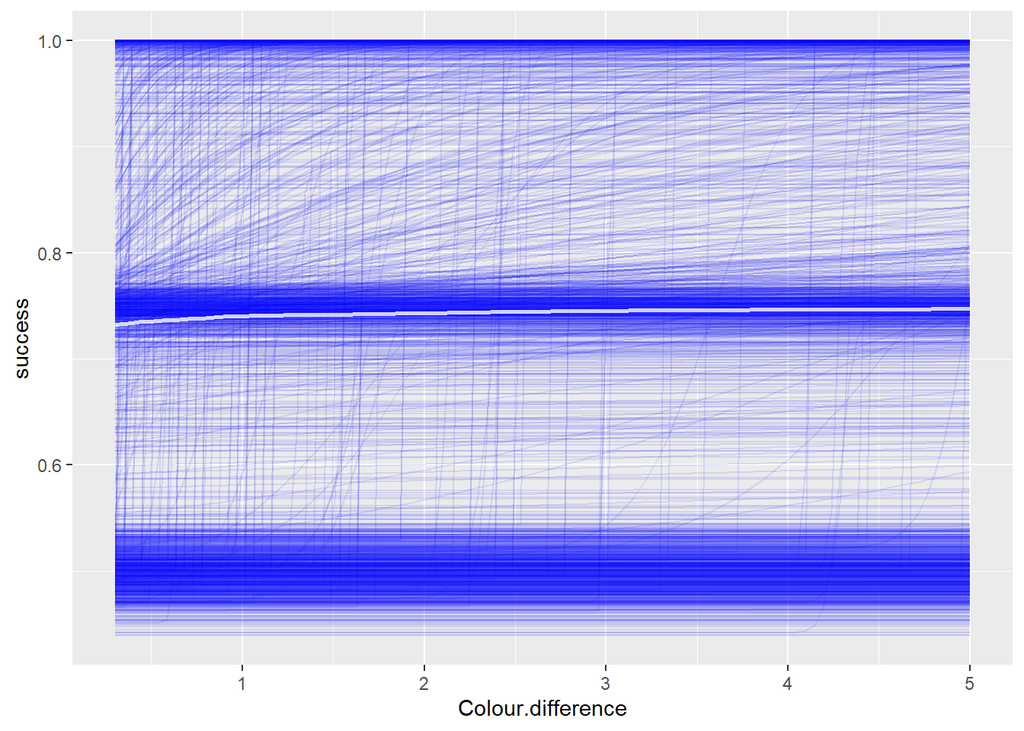

```r
Prior.cond <- conditional_effects(Prior.fit, spaghetti = TRUE, effects = "Colour.difference")
plot(Prior.cond)
```

The plot above shows the model fit at every iteration when using only the priors and not the data. Many values are possible, including many different slopes for the line, though there is definite concentration at certain values.

### Run the Model

200 or 2000 iterations give similar results to 10000. Random effects of threshold and width should change together (ideally, explicit correllation). and setting initial values to 0 is a work-around.

```r
Bayes.fit <- brm( formula = frm1,
               data = cd.long, family = bernoulli("identity"),
             prior = prr1,
             #finely sampled
                control = list(adapt_delta = 0.99),
                inits = 0,
                iter = 2000  )
```

```
## recompiling to avoid crashing R session
```

### Inspect the model

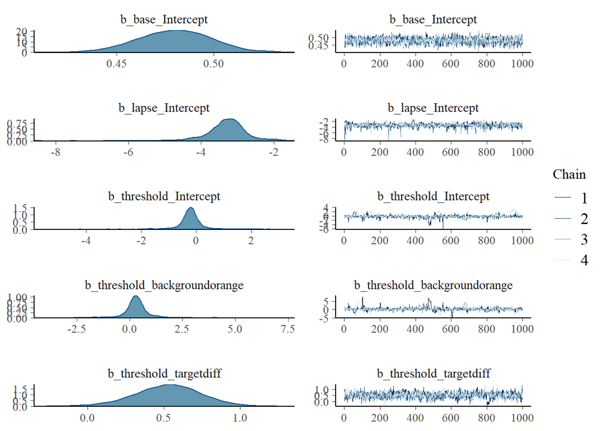

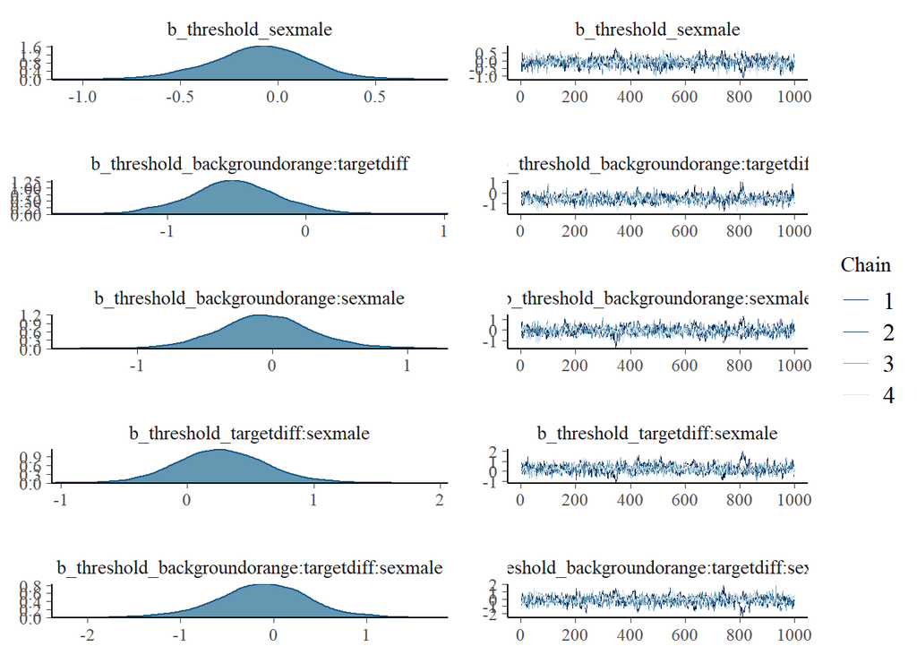

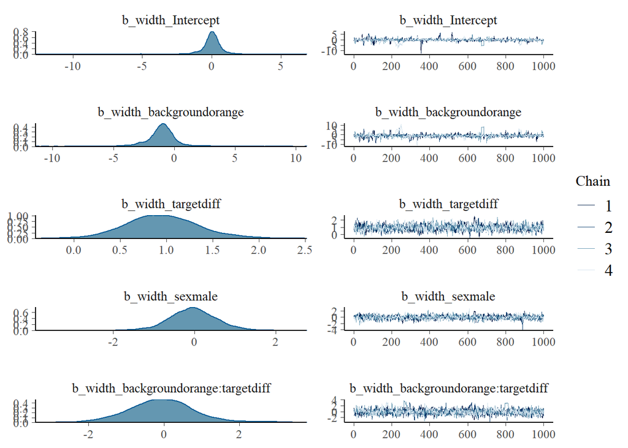

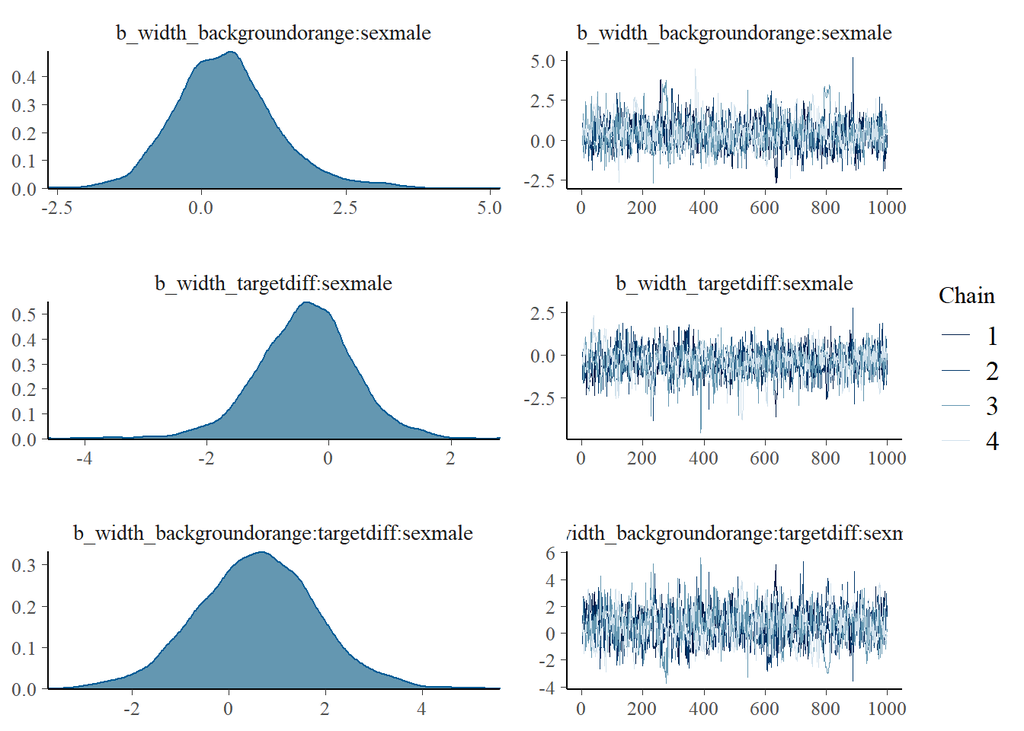

```r
plot(Bayes.fit,type="dens_overlay", pars = "^b_")
```

Derive summary information

```r
summary(Bayes.fit)
```

```
##  Family: bernoulli
##   Links: mu = identity
## Formula: success ~ base + (1 - inv_logit(lapse) - base) * inv_logit(4.39 * (Colour.difference - exp(threshold))/(exp(width)))
##          base ~ 1
##          lapse ~ 1 + (1 | chick) + (1 | batch)
##          threshold ~ background * target * sex + (1 | chick) + (1 | batch)
##          width ~ background * target * sex + (1 | chick) + (1 | batch)
##    Data: cd.long (Number of observations: 6560)
## Samples: 4 chains, each with iter = 2000; warmup = 1000; thin = 1;
##          total post-warmup samples = 4000
##
## Group-Level Effects:
## ~batch (Number of levels: 4)
##                         Estimate Est.Error l-95% CI u-95% CI Rhat Bulk_ESS
## sd(lapse_Intercept)         0.89      0.88     0.05     3.22 1.00      669
## sd(threshold_Intercept)     0.54      0.87     0.01     3.22 1.00      410
## sd(width_Intercept)         0.99      1.32     0.03     4.90 1.01      505
##                         Tail_ESS
## sd(lapse_Intercept)          996
## sd(threshold_Intercept)      389
## sd(width_Intercept)          456
##
## ~chick (Number of levels: 32)
##                         Estimate Est.Error l-95% CI u-95% CI Rhat Bulk_ESS
## sd(lapse_Intercept)         0.72      0.23     0.34     1.23 1.00      704
## sd(threshold_Intercept)     0.29      0.07     0.18     0.45 1.01      990
## sd(width_Intercept)         0.34      0.18     0.03     0.73 1.00      682
##                         Tail_ESS
## sd(lapse_Intercept)          757
## sd(threshold_Intercept)     1544
## sd(width_Intercept)          690
##
## Population-Level Effects:
##                                               Estimate Est.Error l-95% CI
## base_Intercept                                    0.48      0.02     0.44
## lapse_Intercept                                  -3.30      0.58    -4.54
## threshold_Intercept                              -0.19      0.61    -1.47
## threshold_backgroundorange                        0.33      0.84    -1.46
## threshold_targetdiff                              0.52      0.22     0.06
## threshold_sexmale                                -0.09      0.26    -0.64
```

[output cut: 20 more lines]

```
## threshold_backgroundorange:sexmale                0.68 1.01      579      806
## threshold_targetdiff:sexmale                      1.03 1.00      452      742
## threshold_backgroundorange:targetdiff:sexmale     0.87 1.00      524      766
## width_Intercept                                   1.84 1.01      660      314
## width_backgroundorange                            2.63 1.01      733      403
## width_targetdiff                                  1.78 1.00     1064     1362
## width_sexmale                                     1.11 1.00      893     1335
## width_backgroundorange:targetdiff                 1.96 1.00      852      646
## width_backgroundorange:sexmale                    2.40 1.00      764      622
## width_targetdiff:sexmale                          1.14 1.00      856     1382
## width_backgroundorange:targetdiff:sexmale         3.04 1.01      768      752
##
## Samples were drawn using sampling(NUTS). For each parameter, Bulk_ESS
## and Tail_ESS are effective sample size measures, and Rhat is the potential
## scale reduction factor on split chains (at convergence, Rhat = 1).
```

The ESS and Rhat values confirm that the model converged well. Divergent transitions indicate that a between MC draws an unexpected transition has occurred.

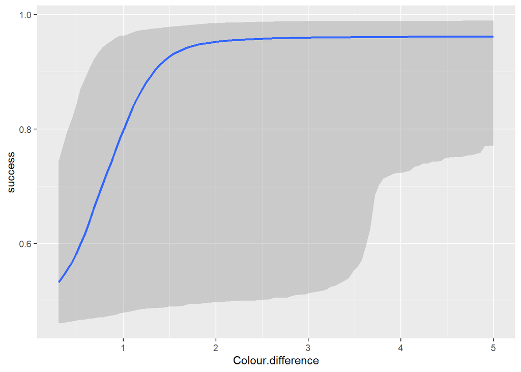

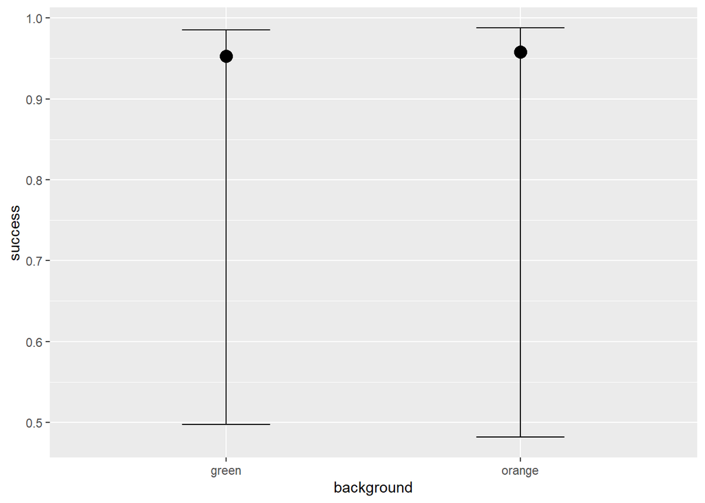

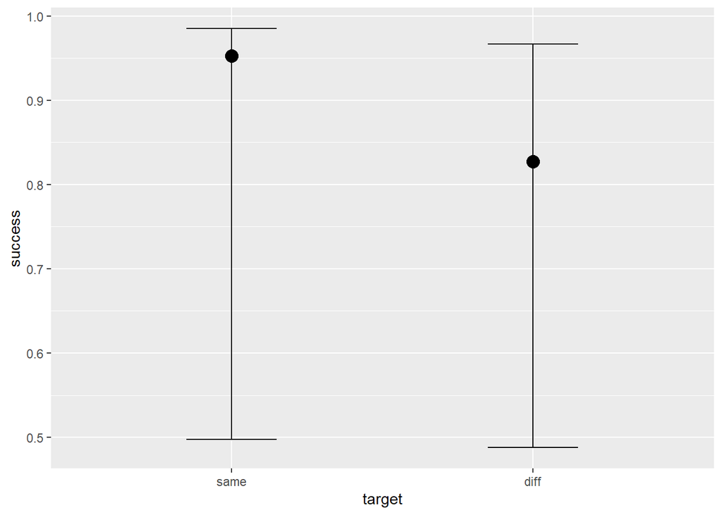

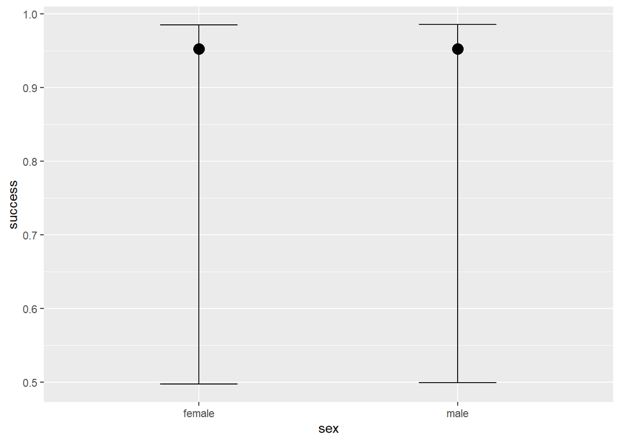

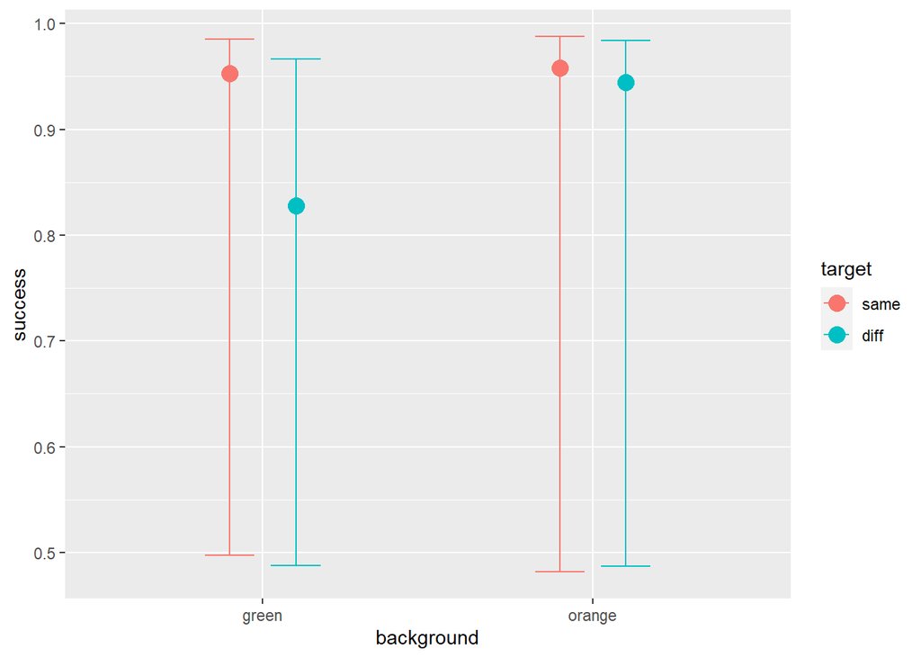

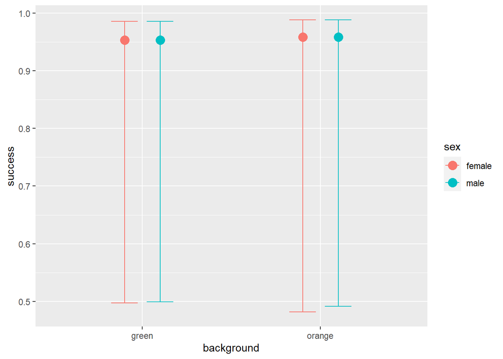

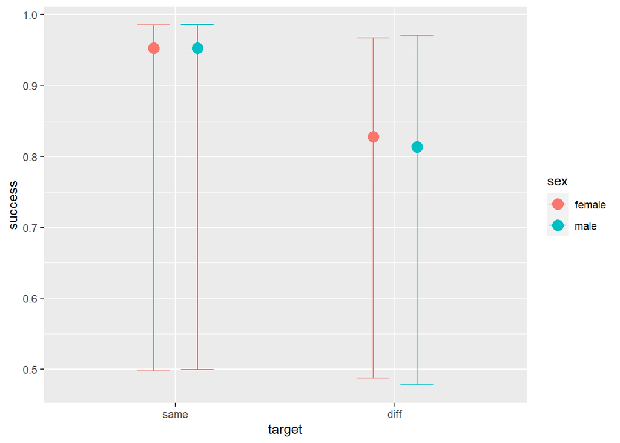

```r
conditional_effects(Bayes.fit)
```

Conditional effects at the mean is used to investigate certain parameters at the mean values of the remaining parameters.

## Posterior predictive checks (PPCs)

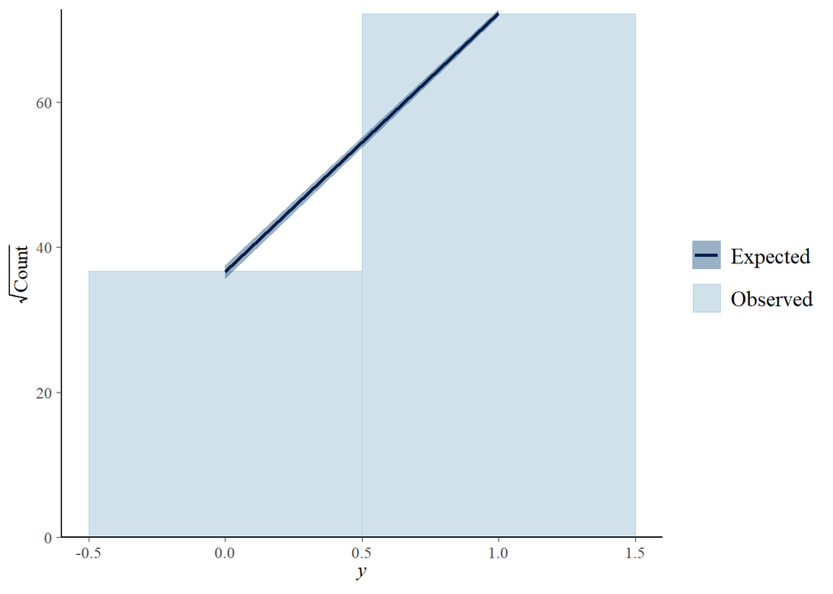

```r
pp_check(Bayes.fit,
         type = "rootogram", nsamples=2000, prob = 0.9, size = 1)
```

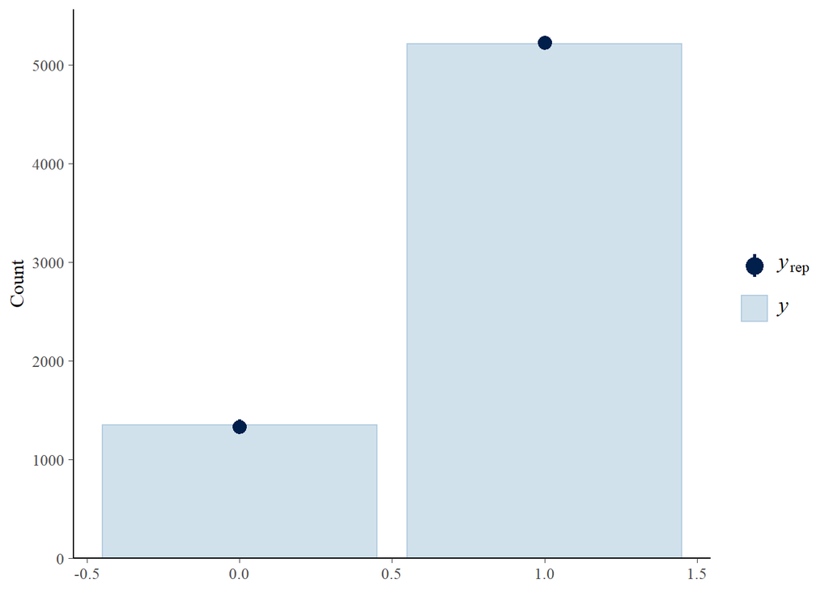

```r
pp_check(Bayes.fit,
         type = "bars", nsamples=200, prob = 0.9, size = 1)
```

These checks show that the predctions are consistent with the observed data.